# Multivariate Analysis of Field Samples

Trevor Eakes

July 02, 2025

# Data Import and Preparation

In this first step, I read in the merged field dataset and added a numeric Lab_Num identifier so I can focus on samples Lab_01 through Lab_22.

```r
source("process_plate_run.R")
data <- read_excel("full_merged_data_manual_fix.xlsx")
#
data <- data %>%
  mutate(Lab_Num = as.numeric(sub("Lab_", "", join_id)))
data$Protein_mg_per_g_mean <- data$Protein_mg_per_g_mean %>% as.numeric()
data$PE_mg_per_g_sample_mean <- data$PE_mg_per_g_sample_mean %>% as.numeric()
data$carb_mg_per_g_mean <- data$carb_mg_per_g_mean %>% as.numeric()
data$ash_per_mean <- data$ash_per_mean %>% as.numeric()
data$PE_pred_run2_mg_per_g_mean <- data$PE_pred_run2_mg_per_g_mean %>% as.numeric()
data$Kappa_Index <- data$Kappa_Index %>% as.numeric()
data$car_per <- data$car_per %>% as.numeric()
data$Iota_Index <- data$Iota_Index %>% as.numeric()
data$Lambda_Index <- data$Lambda_Index %>% as.numeric()
class(data$Protein_mg_per_g_mean)
```

```
## [1] "numeric"
```

# Q1: Is PE higher in somewhere?

I wanted to see if the Ilo region or Locations or Life_S has/have more phycoerythrin (PE) than others, so I ran a kurskal wallace test.

```r
kw_result <- kruskal.test(PE_mg_per_g_sample_mean ~ Location, data = data)
kw_result2 <- kruskal.test(PE_mg_per_g_sample_mean ~ region, data = data)
kw_lifestage_pe <- kruskal.test(PE_mg_per_g_sample_mean ~ Life_S, data = data)

# Print the result
print(kw_result)
```

```
##
##  Kruskal-Wallis rank sum test
##
## data:  PE_mg_per_g_sample_mean by Location
## Kruskal-Wallis chi-squared = 13.958, df = 5, p-value = 0.01588
```

```r
print(kw_result2)
```

```
##
##  Kruskal-Wallis rank sum test
##
## data:  PE_mg_per_g_sample_mean by region
## Kruskal-Wallis chi-squared = 4.695, df = 2, p-value = 0.09561
```

```r
print(kw_lifestage_pe)
```

```
##
##  Kruskal-Wallis rank sum test
##
## data:  PE_mg_per_g_sample_mean by Life_S
## Kruskal-Wallis chi-squared = 6.1259, df = 2, p-value = 0.04675
```

```r
pairwise_result1 <- pairwise.wilcox.test(
  data$PE_mg_per_g_sample_mean,
  data$`Life_S`,
  p.adjust.method = "BH"
)

pairwise_result2 <- pairwise.wilcox.test(
  data$PE_mg_per_g_sample_mean,
  data$Location,
  p.adjust.method = "BH"
)

# Print results
print(pairwise_result1)
```

```
##
##  Pairwise comparisons using Wilcoxon rank sum exact test
##
## data:  data$PE_mg_per_g_sample_mean and data$Life_S
##
##           Carp  Gam/Tetra
## Gam/Tetra 0.142 -
## Unknown   0.091 0.091
##
## P value adjustment method: BH
```

```r
print(pairwise_result2)
```

```
##
##  Pairwise comparisons using Wilcoxon rank sum exact test
##
## data:  data$PE_mg_per_g_sample_mean and data$Location
##
##                        7H   Caro Caido Concession Ilo Mariculture Powder
## Caro Caido             0.40 -          -          -
## Concession             0.06 0.16       -          -
## Ilo Mariculture Powder 0.40 0.56       0.40       -
## Mendieta               0.40 0.46       0.06       0.46
## Powder Ilo             0.16 0.18       0.56       0.40
##                        Mendieta
## Caro Caido             -
## Concession             -
## Ilo Mariculture Powder -
## Mendieta               -
## Powder Ilo             0.16
##
## P value adjustment method: BH
```

```r
#Try faceting Location or region by Life_S
```

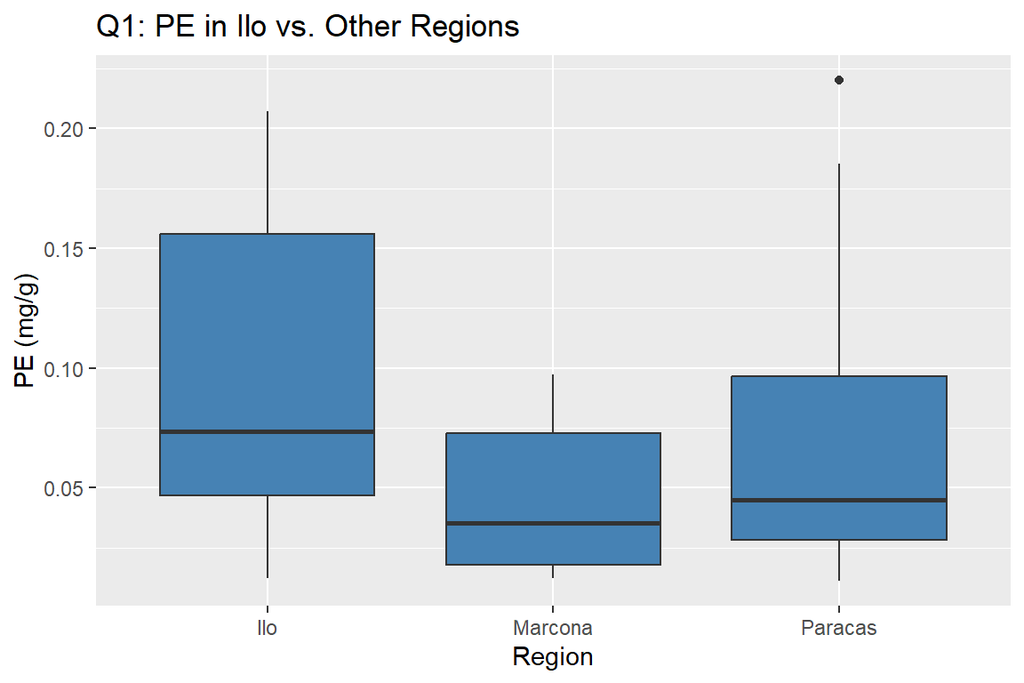

```r
ggplot(data, aes(x = factor(region),
                    y = PE_pred_run2_mg_per_g_mean)) +
  geom_boxplot(fill = "steelblue") +
  labs(x = "Region", y = "PE (mg/g)",
       title = "Q1: PE in Ilo vs. Other Regions")
```

# Q2: Which location has the highest PE?

To find the site with the most PE, I calculated average PE per location and ranked them.

```r
pe_summary <- data %>%
  group_by(Location) %>%
    summarise(n = n(), mean_PE = mean(PE_mg_per_g_sample_mean, na.rm = TRUE)) %>%
  arrange(desc(mean_PE))
pe_summary
```

```
## # A tibble: 6 × 3
##   Location                   n mean_PE
##   <chr>                  <int>   <dbl>
## 1 Powder Ilo                 3  0.101
## 2 Concession                 6  0.0843
## 3 Ilo Mariculture Powder     4  0.0530
## 4 Mendieta                  16  0.0441
## 5 Caro Caido                 5  0.0425
## 6 7H                         8  0.0293
```

# Q3: Protein across region, Location and variety

I checked whether protein content varies by region using a Kruskal–Wallis test because the data aren’t fully normal.

```r
kw_region_prot <- kruskal.test(Protein_mg_per_g_mean ~ region, data = data)
kw_region_prot
```

```
##
##  Kruskal-Wallis rank sum test
##
## data:  Protein_mg_per_g_mean by region
## Kruskal-Wallis chi-squared = 0.0028433, df = 2, p-value = 0.9986
```

```r
kw_location_prot <- kruskal.test(Protein_mg_per_g_mean ~ Location, data =data)
kw_location_prot
```

```
##
##  Kruskal-Wallis rank sum test
##
## data:  Protein_mg_per_g_mean by Location
## Kruskal-Wallis chi-squared = 6.3817, df = 5, p-value = 0.2708
```

```r
kw_lifestage_prot <- kruskal.test(Protein_mg_per_g_mean ~ `Life_S`, data = data)
kw_lifestage_prot
```

```
##
##  Kruskal-Wallis rank sum test
##
## data:  Protein_mg_per_g_mean by Life_S
## Kruskal-Wallis chi-squared = 3.7293, df = 2, p-value = 0.1549
```

# Q4: Comparing varieties in Paracas & Marcona

```r
vm_data <- data %>% dplyr::filter(region %in% c("Paracas","Marcona"), !is.na(variety))
# Protein
wil_var_p <- wilcox.test(
  as.numeric(Protein_mg_per_g_mean) ~ variety,
  data = vm_data
)
# PE
wil_var_pe <- wilcox.test(
  as.numeric(PE_mg_per_g_sample_mean) ~ variety,
  data = vm_data
)
wil_var_p; wil_var_pe
```

```
##
##  Wilcoxon rank sum exact test
##
## data:  as.numeric(Protein_mg_per_g_mean) by variety
## W = 96, p-value = 0.475
## alternative hypothesis: true location shift is not equal to 0
```

```
##
##  Wilcoxon rank sum exact test
##
## data:  as.numeric(PE_mg_per_g_sample_mean) by variety
## W = 139, p-value = 0.4907
## alternative hypothesis: true location shift is not equal to 0
```

# Q5: Protein by Life_S in Paracas & Marcona

Here, I tested protein differences between Life_Ss and plotted results.

```r
# Q5: Protein by `Life_S` across Paracas & Marcona
ls_data <- vm_data %>% dplyr::filter(!is.na(`Life_S`), !is.na(Protein_mg_per_g_mean))
wil_ls <- wilcox.test(
  as.numeric(Protein_mg_per_g_mean) ~ `Life_S`,
  data = ls_data
)
wil_ls
```

```
##
##  Wilcoxon rank sum exact test
##
## data:  as.numeric(Protein_mg_per_g_mean) by Life_S
## W = 140, p-value = 0.3431
## alternative hypothesis: true location shift is not equal to 0
```

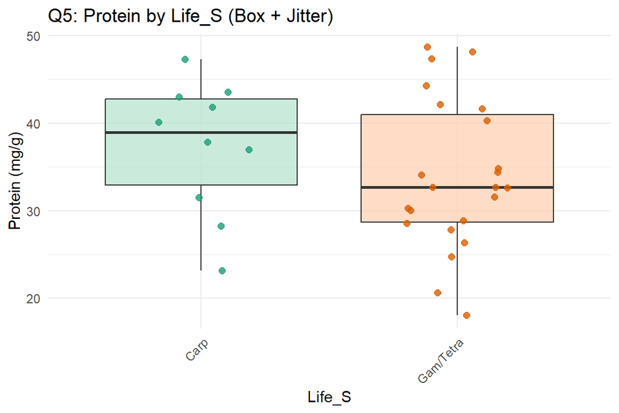

```r
# Enhanced boxplot with jitter for protein by Life_S
p5 <- ggplot(ls_data, aes(x = `Life_S`, y = Protein_mg_per_g_mean, fill = `Life_S`)) +
  geom_boxplot(outlier.shape = NA, alpha = 0.7) +
  geom_jitter(aes(color = `Life_S`), width = 0.2, size = 2, alpha = 0.8) +
  theme_minimal() +
  theme(axis.text.x = element_text(angle = 45, hjust = 1),
        legend.position = "none") +
  scale_fill_brewer(palette = "Pastel2") +
  scale_color_brewer(palette = "Dark2") +
  labs(x = "Life_S", y = "Protein (mg/g)",
       title = "Q5: Protein by Life_S (Box + Jitter)")
print(p5)
```

# Q6: Carrageenan (%) comparisons

```r
car_data <- data %>% dplyr::filter(!is.na(car_per))
kw_var_car <- kruskal.test(car_per ~ variety, data = car_data)
kw_ls_car  <- kruskal.test(car_per ~ `Life_S`, data = car_data)
kw_loc_car <- kruskal.test(car_per ~ Location, data = car_data)
kw_var_car; kw_ls_car; kw_loc_car
```

```
##
##  Kruskal-Wallis rank sum test
##
## data:  car_per by variety
## Kruskal-Wallis chi-squared = 1.3886, df = 1, p-value = 0.2386
```

```
##
##  Kruskal-Wallis rank sum test
##
## data:  car_per by Life_S
## Kruskal-Wallis chi-squared = 10.068, df = 2, p-value = 0.006513
```

```
##
##  Kruskal-Wallis rank sum test
##
## data:  car_per by Location
## Kruskal-Wallis chi-squared = 12.951, df = 4, p-value = 0.01152
```

# Q7: Kappa, Iota, Lambda by groups

```r
kin_data <- data %>% dplyr::filter(!is.na(Kappa_Index) & !is.na(Iota_Index) & !is.na(Lambda_Index))
kin_vars <- c("Kappa_Index","Iota_Index","Lambda_Index")
results <- lapply(kin_vars, function(kin) {
  kruskal.test(as.formula(paste(kin, "~ Life_S")), data = kin_data)
})
results
```

```
## [[1]]
##
##  Kruskal-Wallis rank sum test
##
## data:  Kappa_Index by Life_S
## Kruskal-Wallis chi-squared = 1.1261, df = 2, p-value = 0.5695
##
##
## [[2]]
##
##  Kruskal-Wallis rank sum test
##
## data:  Iota_Index by Life_S
## Kruskal-Wallis chi-squared = 0.12513, df = 2, p-value = 0.9394
##
##
## [[3]]
##
##  Kruskal-Wallis rank sum test
##
## data:  Lambda_Index by Life_S
## Kruskal-Wallis chi-squared = 0.061773, df = 2, p-value = 0.9696
```

#Q8 Does faceting Location comparisons for PE and Protein change things meaningfully?

```r
#################################
#Statistical tests
#################################

filtered_data <- data %>%
  dplyr::filter(`Life_S` %in% c("Carp", "Gam/Tetra"),
         !is.na(variety),
         !is.na(Location),
         !is.na(PE_mg_per_g_sample_mean),
         !is.na(Protein_mg_per_g_mean))
# PE tests
# PE
kw_pe <- filtered_data %>%
  group_by(`Life_S`) %>%
  group_map(~ {
    res <- kruskal.test(PE_mg_per_g_sample_mean ~ Location, data = .x)
    tibble(`Life_S` = .y$Life_S, stat = res$statistic, p = res$p.value)
  }) %>% bind_rows()

# Protein
kw_prot <- filtered_data %>%
  group_by(`Life_S`) %>%
  group_map(~ {
    res <- kruskal.test(Protein_mg_per_g_mean ~ Location, data = .x)
    tibble(`Life_S` = .y$`Life_S`, stat = res$statistic, p = res$p.value)
  }) %>% bind_rows()

print(kw_pe)
```

```
## # A tibble: 2 × 3
##   Life_S     stat      p
##   <chr>     <dbl>  <dbl>
## 1 Carp      0.131 0.937
## 2 Gam/Tetra 9.47  0.0504
```

```r
print(kw_prot)
```

```
## # A tibble: 2 × 3
##   Life_S     stat     p
##   <chr>     <dbl> <dbl>
## 1 Carp       1.09 0.580
## 2 Gam/Tetra  4.36 0.359
```

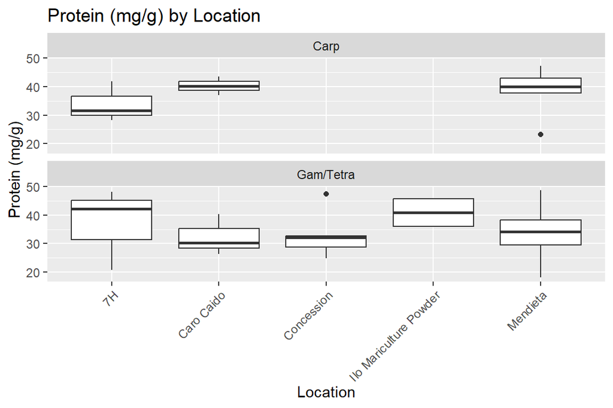

```r
# Save test results
write.csv(kw_pe, "output/PE_KW_by_LifeS.csv", row.names = FALSE)
write.csv(kw_prot, "output/Protein_KW_by_LifeS.csv", row.names = FALSE)

#############################
#plots
#############################
# PE Plot
p_pe <- ggplot(filtered_data, aes(x = Location, y = PE_mg_per_g_sample_mean)) +
  geom_boxplot() +
  facet_wrap(~ `Life_S`, ncol = 1) +
  labs(title = "PE (mg/g) by Location", y = "PE (mg/g)", x = "Location") +
  theme(axis.text.x = element_text(angle = 45, hjust = 1))

ggsave("output/figures/key/PE_by_Location_by_LifeS.png", p_pe)

# Protein Plot
p_prot <- ggplot(filtered_data, aes(x = Location, y = Protein_mg_per_g_mean)) +
  geom_boxplot() +
  facet_wrap(~ `Life_S`, ncol = 1) +
  labs(title = "Protein (mg/g) by Location", y = "Protein (mg/g)", x = "Location") +
  theme(axis.text.x = element_text(angle = 45, hjust = 1))

ggsave("output/figures/key/Protein_by_Location_by_LifeS.png", p_prot)

p_prot
```

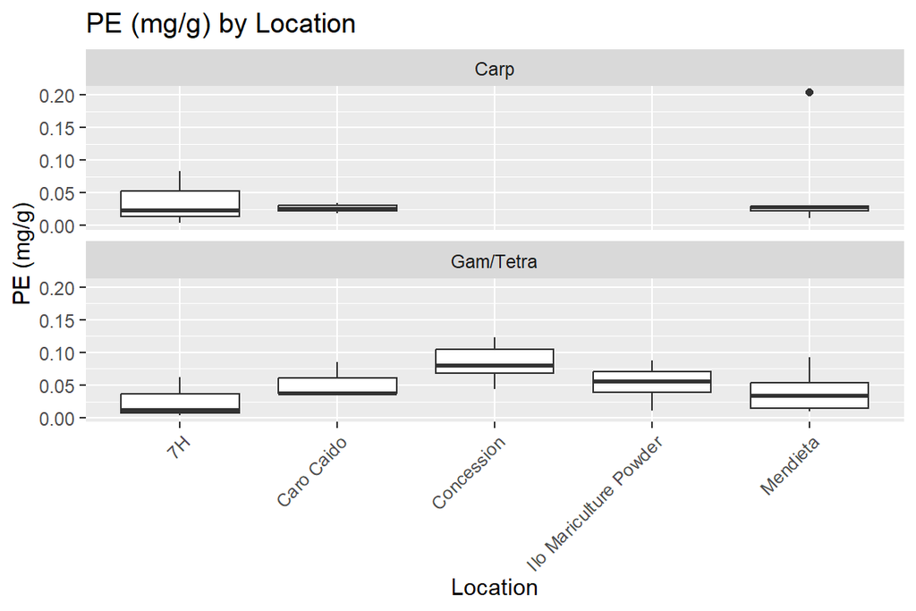

```r
p_pe
```

# Q9 Multivariate Analysis: PERMANOVA

I ran PERMANOVA on all standardized numeric traits for Labs 01–22 to see how `Life_S` and location structure the data. Variety excluded.

```r
# Load packages
library(tidyverse)
library(vegan)
library(ggplot2)
library(ggrepel)
library(patchwork)
library(dendextend)
library(RColorBrewer)

# Create output folder if not exists
dir.create("output/key_figures", recursive = TRUE, showWarnings = FALSE)

# --- Data prep ---
data <- readxl::read_excel("full_merged_data_manual_fix.xlsx")
data <- data %>%
  mutate(Lab_Num = as.numeric(sub("Lab_", "", join_id)))
data$Protein_mg_per_g_mean <- data$Protein_mg_per_g_mean %>% as.numeric()
data$PE_mg_per_g_sample_mean <- data$PE_mg_per_g_sample_mean %>% as.numeric()
data$carb_mg_per_g_mean <- data$carb_mg_per_g_mean %>% as.numeric()
data$ash_per_mean <- data$ash_per_mean %>% as.numeric()
data$PE_pred_run2_mg_per_g_mean <- data$PE_pred_run2_mg_per_g_mean %>% as.numeric()
data$Kappa_Index <- data$Kappa_Index %>% as.numeric()
data$car_per <- data$car_per %>% as.numeric()
data$Iota_Index <- data$Iota_Index %>% as.numeric()
data$Lambda_Index <- data$Lambda_Index %>% as.numeric()


# Clean & filter to Lab_01–22
data <- data %>%
  dplyr::filter(str_detect(join_id, "^Lab_")) %>%
  mutate(Lab_Num = as.numeric(str_extract(join_id, "\\d+"))) %>%
  dplyr::filter(Lab_Num >= 1 & Lab_Num <= 22)

# Select numeric traits and metadata
numeric_cols <- names(data)[sapply(data, is.numeric) & !names(data) %in% c("Lab_Num", "t_rep_number")]
meta_df <- data %>%
  dplyr::select(join_id, `Life_S`, Location) %>%
  mutate(across(c(`Life_S`, Location), as.factor))

# Prepare numeric data, scale, and handle NAs
num_df <- data %>%
  dplyr::select(all_of(numeric_cols)) %>%
  mutate(across(everything(), as.numeric)) %>%
  mutate(across(everything(), ~replace_na(., mean(., na.rm = TRUE)))) %>%
  scale() %>% as.data.frame()

# Set rownames for ordination matching
rownames(num_df) <- data$join_id
rownames(meta_df) <- data$join_id

# --- Compute distance matrix ---
dist_mat <- vegdist(num_df, method = "euclidean")

# --- Dispersion plots and ANOVA test ---
for (f in c("Life_S", "Location")) {
  disp <- betadisper(dist_mat, meta_df[[f]])

  # Run ANOVA to test homogeneity of multivariate dispersion
  disp_anova <- anova(disp)
  print(paste("Test for homogeneity of dispersion across", f))
  print(disp_anova)

  # Optional: test pairwise differences if significant
  # if (disp_anova$`Pr(>F)`[1] < 0.05) {
  #   print(TukeyHSD(disp))
  # }

  # Plot
  png(paste0("output/key_figures/dispersion_", f, ".png"), width = 800, height = 600)
  plot(disp, main = paste("Dispersion by", f))
  dev.off()
}
```

```
## [1] "Test for homogeneity of dispersion across Life_S"
## Analysis of Variance Table
##
## Response: Distances
##           Df Sum Sq Mean Sq F value Pr(>F)
## Groups     2  2.280  1.1400  0.6323 0.5422
## Residuals 19 34.254  1.8028
```

```
## [1] "Test for homogeneity of dispersion across Location"
## Analysis of Variance Table
##
## Response: Distances
##           Df  Sum Sq Mean Sq F value Pr(>F)
## Groups     4  2.2862 0.57154  0.6075 0.6627
## Residuals 17 15.9931 0.94077
```

```r
#Outliers
# Compute Mahalanobis distances from the center
center <- colMeans(num_df, na.rm = TRUE)
cov_matrix <- cov(num_df)
mahal_dist <- mahalanobis(num_df, center, cov_matrix)

# Threshold for outlier detection: typically top 5%
threshold <- quantile(mahal_dist, 0.95)
outliers <- which(mahal_dist > threshold)

# Print potential outliers
cat("Potential outliers based on Mahalanobis distance:\n")
```

```
## Potential outliers based on Mahalanobis distance:
```

```r
print(rownames(num_df)[outliers])
```

```
## [1] "Lab_13" "Lab_14"
```

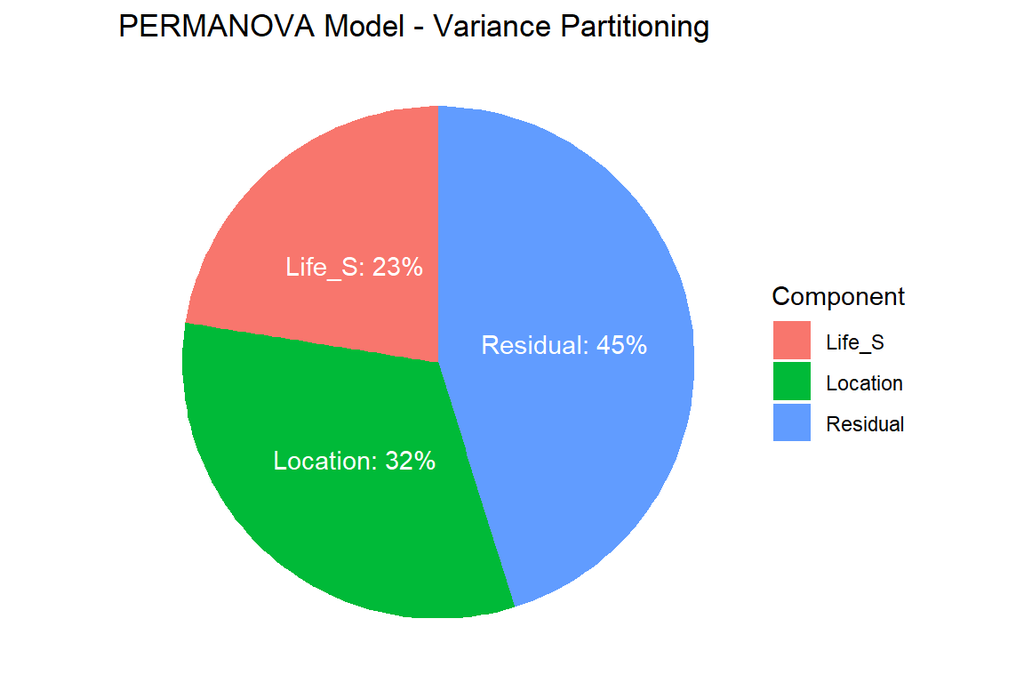

```r
# --- PCoA plot with biplot ---
pcoa <- cmdscale(dist_mat, eig = TRUE, k = 2)
site_scores <- as.data.frame(pcoa$points)
colnames(site_scores) <- c("PC1", "PC2")
site_scores$join_id <- rownames(site_scores)
plot_df <- left_join(site_scores, meta_df, by = "join_id")
variance_explained_percent <- (pcoa$eig / sum(pcoa$eig)) * 100

# Mark outliers in PCoA plotting data
plot_df$outlier <- rownames(plot_df) %in% rownames(num_df)[outliers]
# Prepare outlier data for overlay (join with plot_df to get coordinates)
outlier_df <- plot_df %>%
  dplyr::filter(join_id %in% rownames(num_df)[outliers])

# --- Fit environmental variables using envfit ---
fit <- envfit(pcoa, num_df, perm = 999)
narrow_df <- as.data.frame(fit$vectors$arrows * sqrt(fit$vectors$r))
colnames(narrow_df) <- c("PC1", "PC2")
narrow_df$variable <- rownames(narrow_df)
narrow_df$p_value <- fit$vectors$pvals[narrow_df$variable]
narrow_df$r_squared <- fit$vectors$r[narrow_df$variable]

# --- Abbreviate variable names ---
var_labels <- tribble(
  ~variable,                         ~label,
  "PE_mg_per_g_sample_mean",       "PE",
  "PE_pred_run2_mg_per_g_mean",    "PE_pred",
  "Protein_mg_per_g_mean",         "Prot",
  "ash_per_mean",                  "Ash",
  "carb_mg_per_g_mean",            "Carb",
  "car_per",                        "Carr",
  "Iota_Index",                    "Iota",
  "Kappa_Index",                   "Kappa",
  "Lambda_Index",                  "Lambda"
)
narrow_df <- left_join(narrow_df, var_labels, by = "variable") %>%
  dplyr::filter(!is.na(label)) %>%
  mutate(label = factor(label, levels = label))
#
# Prepare outlier data for overlay (join with plot_df to get coordinates)


# --- Scale arrows ---
scale_factor <- 3.5
narrow_df <- narrow_df %>%
  mutate(PC1 = PC1 * scale_factor,
         PC2 = PC2 * scale_factor)

biplot <- ggplot(plot_df, aes(x = PC1, y = PC2)) +
  geom_point(aes(color = Location, shape = `Life_S`), size = 3) +
  # Overlay outlier stars
  geom_point(data = outlier_df, aes(x = PC1, y = PC2),
             shape = 1, size = 1, stroke = 1, color = "red") +
  geom_segment(data = narrow_df,
               aes(x = 0, y = 0, xend = PC1, yend = PC2),
               arrow = arrow(length = unit(0.2, "cm")), color = "black") +
  geom_text_repel(data = narrow_df,
                  aes(x = PC1, y = PC2, label = label),
                  size = 3, max.overlaps = Inf) +
  labs(x = paste0("PC1 (", variance_explained_percent[1], "%)"),
       y = paste0("PC2 (", variance_explained_percent[2], "%)"),
       title = "PCoA with Nutrient Biplot and Outliers Highlighted") +
  coord_fixed() +
  theme_minimal()

# Save to file
ggsave("output/key_figures/pcoa_biplot_with_outliers.png", plot = biplot, width = 8, height = 6, dpi = 300)

# --- Marginal and Conditional PERMANOVA (with by = "terms") ---
perm_terms <- adonis2(dist_mat ~ `Life_S` + Location, data = meta_df, permutations = 999, by = "terms")

# --- Table of explained variation per term ---
permanova_table <- perm_terms %>%
  as_tibble(rownames = "Component") %>%
  dplyr::select(Component, R2, F, `Pr(>F)`) %>%
  rename(p = `Pr(>F)`)

# Add residual row manually if needed
resid_row <- tibble(Component = "Residual", R2 = 1 - sum(permanova_table$R2), F = NA, p = NA)
permanova_table <- bind_rows(permanova_table, resid_row)
permanova_table2 <- permanova_table[1:3,]

# --- Pie chart of explained variance ---
pie_plot <- ggplot(permanova_table2, aes(x = "", y = R2, fill = Component)) +
  geom_col(width = 1) +
  coord_polar(theta = "y") +
  labs(title = "PERMANOVA Model - Variance Partitioning", x = NULL, y = NULL) +
  theme_void() +
  geom_text(aes(label = paste0(Component, ": ", round(R2 * 100), "%")),
            position = position_stack(vjust = 0.5), color = "white")

pie_plot
```

```r
ggsave("output/key_figures/variance_pie.png", plot = pie_plot, width = 8, height = 6, dpi = 300)
#
# PERMANOVA with marginal terms
perm_terms <- adonis2(dist_mat ~ `Life_S` + Location, data = meta_df, permutations = 999, by = "terms")

# Full model for total explained variance
perm_full <- adonis2(dist_mat ~ `Life_S` + Location, data = meta_df, permutations = 999)

# Extract R² values
r2_life     <- perm_terms["Life_S", "R2"]
r2_location <- perm_terms["Location", "R2"]
r2_total    <- perm_full$R2[1]
r2_residual <- 1 - r2_total

# Prepare a table
venn_table <- tibble::tibble(
  Component = c("Life_S", "Location", "Residual", "Total"),
  R2 = c(r2_life, r2_location, r2_residual, r2_total)
)
print(venn_table)
```

```
## # A tibble: 4 × 2
##   Component    R2
##   <chr>     <dbl>
## 1 Life_S    0.225
## 2 Location  0.323
## 3 Residual  0.452
## 4 Total     0.548
```

```r
#
varpart_model <- varpart(num_df, ~ `Life_S`, ~ Location, data = meta_df)
#variation partititioning model results
print(varpart_model)
```

```
##
## Partition of variance in RDA
##
## Call: varpart(Y = num_df, X = ~Life_S, ~Location, data = meta_df)
##
## Explanatory tables:
## X1:  ~Life_S
## X2:  ~Location
##
## No. of explanatory tables: 2
## Total variation (SS): 189
##             Variance: 9
## No. of observations: 22
##
## Partition table:
##                      Df R.squared Adj.R.squared Testable
## [a+c] = X1            2   0.22504       0.14346     TRUE
## [b+c] = X2            4   0.53656       0.42751     TRUE
## [a+b+c] = X1+X2       5   0.54810       0.40689     TRUE
## Individual fractions
## [a] = X1|X2           1                -0.02063     TRUE
## [b] = X2|X1           3                 0.26343     TRUE
## [c]                   0                 0.16409    FALSE
## [d] = Residuals                         0.59311    FALSE
## ---
## Use function 'rda' to test significance of fractions of interest
```

```r
# Plot Venn-style variation partitioning
png("output/key_figures/variation_partitioning.png", width = 800, height = 600)
plot(varpart_model,
     bg = c("lightblue", "lightgreen"),
     Xnames = c("Life_S", "Location"),
     id.size = 1.2, cex = 1.4,
     main = "Variation Partitioning of Nutrient Traits")

# --- Dendrogram colored by Location, labeled by Life_S ---
hc <- hclust(dist_mat, method = "average")
dend <- as.dendrogram(hc)
label_order <- labels(dend)
meta_ordered <- meta_df[label_order, ]

# Replace labels with Life_S
dend <- dend %>% set("labels", as.character(meta_ordered$`Life_S`))

# Color labels by Location
location_labels <- as.character(meta_ordered$Location)
location_levels <- unique(location_labels)
palette <- RColorBrewer::brewer.pal(length(location_levels), "Set1")
label_colors <- setNames(palette, location_levels)
dend_colors <- label_colors[location_labels]

dend <- dend %>%
  set("labels_col", dend_colors) %>%
  set("labels_cex", 1.4)

png("output/key_figures/dendrogram_lifestage_colored_by_location.png", width = 1000, height = 600)
plot(dend, main = "Dendrogram Labeled by Life_S, Colored by Location", font.main = 2)
legend("topright", legend = location_levels, fill = palette, title = "Location", cex = 0.9)
##
```

# Study Design Summary

Below is a table summarizing the study design by location: number of replicates, Life_S counts, presence and counts of F. Glom, constant depth, and number of observations for each measured variable.

**Study Design Summary by Location**

Replicates, `Life_S`s, F. Glom presence, Depth, and Obs counts

[output not shown]

#Q10: Does carrageenan corellate with ash or carbohydrate content

```r
# Filter to rows with all three variables present
q10_data <- data %>%
  dplyr::select(Location, car_per, carb_mg_per_g_mean, ash_per_mean) %>%
  drop_na()

# Step 1: Identify only numeric columns
numeric_cols <- data %>% dplyr::select(where(is.numeric)) %>% colnames()

# Step 2: Filter rows where all numeric columns are > 0 (and not NA)
data_clean <- data %>%
  dplyr::filter(if_all(all_of(numeric_cols), ~ !is.na(.) & . > 0))

# Step 3: Summarize number of replicates per Location
location_summary <- data_clean %>%
  dplyr::filter(!is.na(Location)) %>%
  group_by(Location) %>%
  summarise(replicates = n(), .groups = "drop")

print(location_summary)
```

```
## # A tibble: 5 × 2
##   Location   replicates
##   <chr>           <int>
## 1 7H                  3
## 2 Caro Caido          3
## 3 Concession          2
## 4 Mendieta            6
## 5 Powder Ilo          3
```

```r
# Run linear regressions
lm_carb <- lm(car_per ~ carb_mg_per_g_mean, data = q10_data)
lm_ash  <- lm(car_per ~ ash_per_mean, data = q10_data)

# Save model summaries
summary_carb <- summary(lm_carb)
summary_ash  <- summary(lm_ash)

print(summary_carb)
```

```
##
## Call:
## lm(formula = car_per ~ carb_mg_per_g_mean, data = q10_data)
##
## Residuals:
##      Min       1Q   Median       3Q      Max
## -0.28930 -0.13945  0.02116  0.13854  0.29359
##
## Coefficients:
##                     Estimate Std. Error t value Pr(>|t|)
## (Intercept)        0.3756966  0.3187147   1.179    0.257
## carb_mg_per_g_mean 0.0004896  0.0039288   0.125    0.902
##
## Residual standard error: 0.1893 on 15 degrees of freedom
## Multiple R-squared:  0.001034,   Adjusted R-squared:  -0.06556
## F-statistic: 0.01553 on 1 and 15 DF,  p-value: 0.9025
```

```r
print(summary_ash)
```

```
##
## Call:
## lm(formula = car_per ~ ash_per_mean, data = q10_data)
##
## Residuals:
##      Min       1Q   Median       3Q      Max
## -0.26037 -0.11498  0.03392  0.10723  0.16870
##
## Coefficients:
##              Estimate Std. Error t value Pr(>|t|)
## (Intercept)   -0.2610     0.1989  -1.312  0.20928
## ash_per_mean   2.2794     0.6608   3.450  0.00357 **
## ---
## Signif. codes:  0 '***' 0.001 '**' 0.01 '*' 0.05 '.' 0.1 ' ' 1
##
## Residual standard error: 0.1414 on 15 degrees of freedom
## Multiple R-squared:  0.4424, Adjusted R-squared:  0.4052
## F-statistic:  11.9 on 1 and 15 DF,  p-value: 0.003575
```

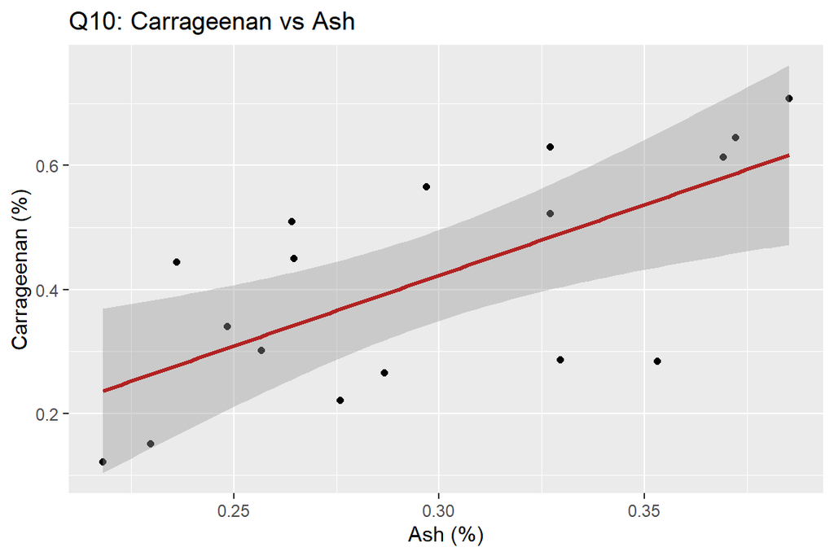

```r
# Export summary results
write.csv(broom::tidy(summary_carb), "output/Q10_lm_carrageenan_vs_carb.csv", row.names = FALSE)
write.csv(broom::tidy(summary_ash),  "output/Q10_lm_carrageenan_vs_ash.csv",  row.names = FALSE)

# Make plots
p10_carb <- ggplot(q10_data, aes(x = carb_mg_per_g_mean, y = car_per)) +
  geom_point() +
  geom_smooth(method = "lm", se = TRUE, color = "steelblue") +
  labs(title = "Q10: Carrageenan vs Carbohydrates",
       x = "Carbohydrates (mg/g)", y = "Carrageenan (%)")

p10_ash <- ggplot(q10_data, aes(x = ash_per_mean, y = car_per)) +
  geom_point() +
  geom_smooth(method = "lm", se = TRUE, color = "firebrick") +
  labs(title = "Q10: Carrageenan vs Ash",
       x = "Ash (%)", y = "Carrageenan (%)")

p10_ash
```

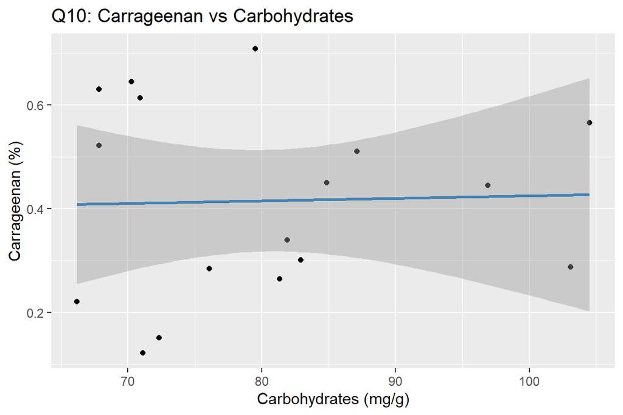

```r
p10_carb
```

```r
# Save plots
ggsave("output/figures/key/Q10_carrageenan_vs_carb.png", p10_carb)
ggsave("output/figures/key/Q10_carrageenan_vs_ash.png",  p10_ash)
```